# Pricing Pegged HKD/USD Options with Jump-Augmented Uniform Distribution

## 1. Model Setup

We model the HKD/USD spot rate $R$ as:

$R = R_{\text{uniform}} + R_{\text{jump}}$

Where:

- $R_{\text{uniform}} \sim \mathcal{U}(7.75, 7.85)$
- $R_{\text{jump}} \in \{-\delta, 0, +\delta\}$ with probabilities $q$, $p$, and $1 - p - q$

So $R$ is a mixture of three uniform distributions:

- Jump down: $R \sim \mathcal{U}(7.75 - \delta, 7.85 - \delta)$, with weight $q$
- No jump: $R \sim \mathcal{U}(7.75, 7.85)$, with weight $p$
- Jump up: $R \sim \mathcal{U}(7.75 + \delta, 7.85 + \delta)$, with weight $1 - p - q$

## 2. Forward Pricing Condition

The forward price satisfies:

$\ln\left( \frac{F}{S} \right) = \mathbb{E}[R_{\text{jump}}] = \delta (1 - p - 2q)$

## 3. Call Option Pricing

We compute the expected value of $\max(R - K, 0)$ over each interval $[a, b]$:

Define:

- $C_{\text{down}}(\delta)$ over $\mathcal{U}(7.75 - \delta, 7.85 - \delta)$
- $C_{\text{mid}}$ over $\mathcal{U}(7.75, 7.85)$
- $C_{\text{up}}(\delta)$ over $\mathcal{U}(7.75 + \delta, 7.85 + \delta)$

Then the call price is:

$\text{Call} = q \cdot C_{\text{down}} + p \cdot C_{\text{mid}} + (1 - p - q) \cdot C_{\text{up}}$

## 4. Put Option Pricing

Similarly, the expectation of $(K - R)^+$ over $[a, b]$ is:

Define:

- $P_{\text{down}}(\delta)$ over $\mathcal{U}(7.75 - \delta, 7.85 - \delta)$
- $P_{\text{mid}}$ over $\mathcal{U}(7.75, 7.85)$
- $P_{\text{up}}(\delta)$ over $\mathcal{U}(7.75 + \delta, 7.85 + \delta)$

Then the put price is:

$\text{Put} = q \cdot P_{\text{down}} + p \cdot P_{\text{mid}} + (1 - p - q) \cdot P_{\text{up}}$

## 5. System of Equations

We solve the following system for $(p, q, \delta)$:

- $\text{Call}(p, q, \delta) = \text{Call}_{\text{mkt}}$
- $\text{Put}(p, q, \delta) = \text{Put}_{\text{mkt}}$
- $\delta (1 - p - 2q) = \ln(F/S)$

```python
import numpy as np
from scipy.optimize import fsolve

# --- Call and Put component integrals over uniform interval ---
def call_component(K, a, b):
    if K >= b:
        return 0
    elif K <= a:
        return (b - K) ** 2 / (2 * (b - a))
    else:
        return ((b - K) ** 2 - (a - K) ** 2) / (2 * (b - a))

def put_component(K, a, b):
    if K <= a:
        return 0
    elif K >= b:
        return (K - a) ** 2 / (2 * (b - a))
    else:
        return ((K - a) ** 2) / (2 * (b - a))

# --- Total Call and Put prices under mixture model ---
def call_price(p, q, delta, K):
    down = call_component(K, 7.75 - delta, 7.85 - delta)
    mid  = call_component(K, 7.75, 7.85)
    up   = call_component(K, 7.75 + delta, 7.85 + delta)
    return q * down + p * mid + (1 - p - q) * up

def put_price(p, q, delta, K):
    down = put_component(K, 7.75 - delta, 7.85 - delta)
    mid  = put_component(K, 7.75, 7.85)
    up   = put_component(K, 7.75 + delta, 7.85 + delta)
    return q * down + p * mid + (1 - p - q) * up

# --- Expected forward/spot jump adjustment ---
def fwd_jump_diff(p, q, delta, fwd, spot):
    return delta * (1 - p - 2 * q) - np.log(fwd / spot)

# --- System of equations to solve for p, q, delta ---
def equations(vars, K, call_market, put_market, fwd, spot):
    p, q, delta = vars
    return [
        call_price(p, q, delta, K) - call_market,
        put_price(p, q, delta, K) - put_market,
        fwd_jump_diff(p, q, delta, fwd, spot)
    ]

# Example market inputs (replace with real data)
spot = 7.80
fwd = 7.81
K = 7.80
call_market = 0.010
put_market = 0.008
x0 = [0.4, 0.2, 0.01]  # initial guess: p, q, delta

# Solve the system
sol = fsolve(equations, x0, args=(K, call_market, put_market, fwd, spot))
p, q, delta = sol

(p, q, delta)
```

```
(0.8968389792217281, -0.06158253448085114, 0.026241849727635484)
```

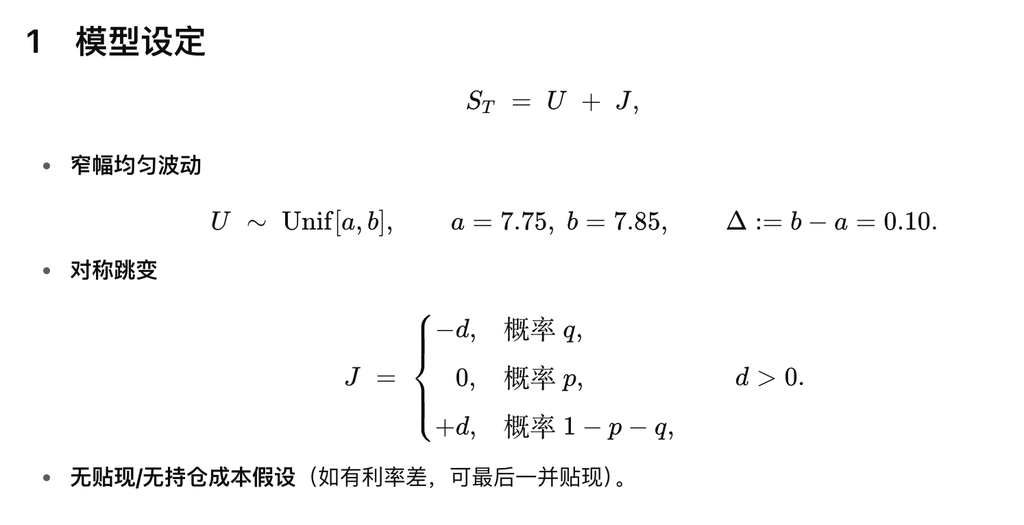

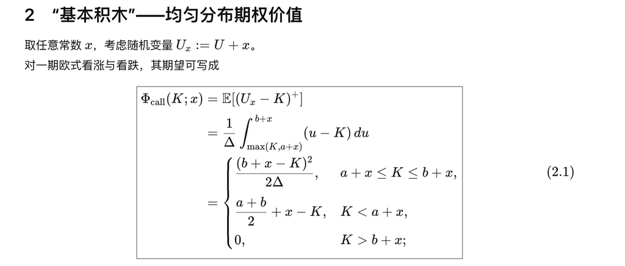

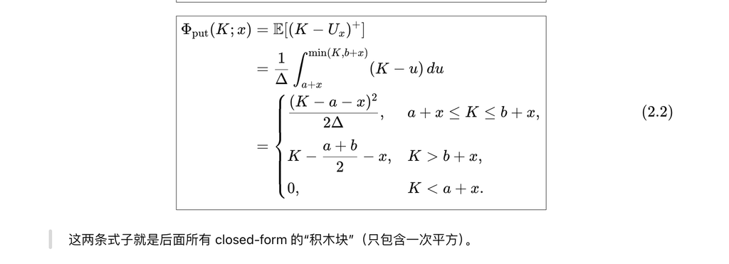

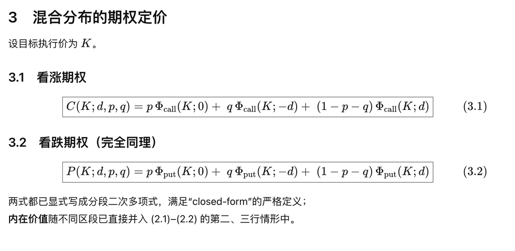

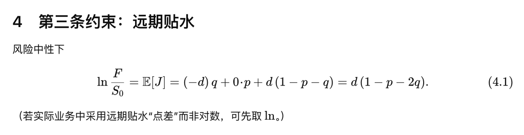

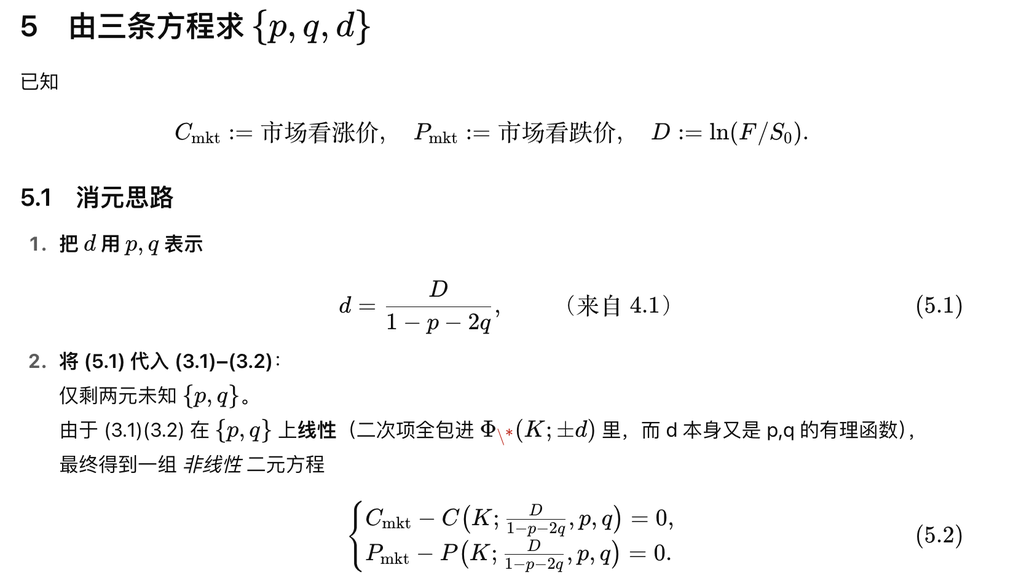

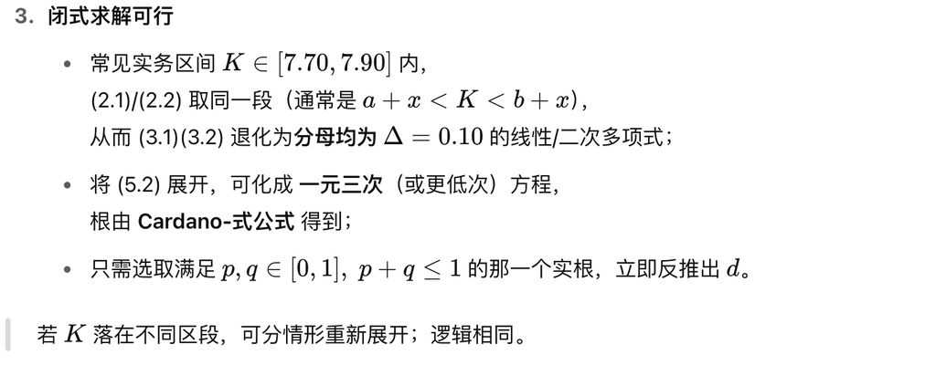

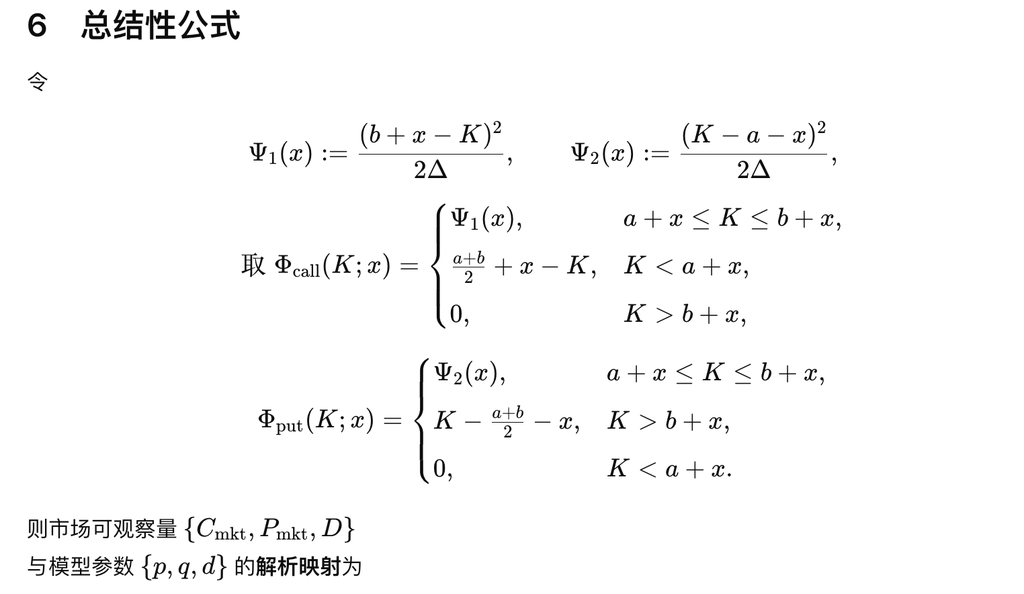

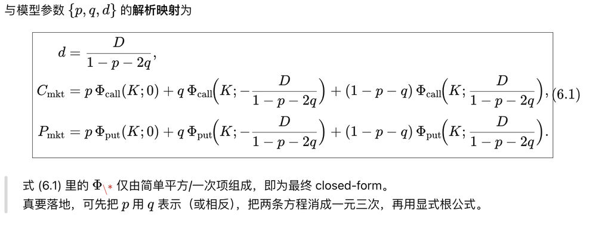

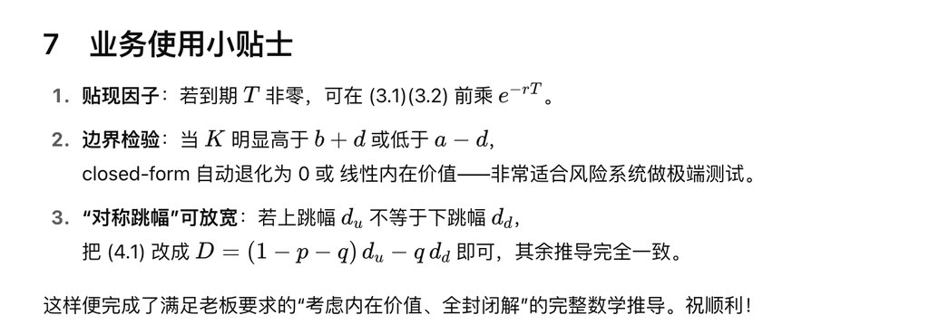